# Coursera Captstone Milestone Report

SwiftKey Application Exploratory Analysis

Joel Hickman

8/25/2020

### Overview and Executive Summary

In this project, I will use the *SwiftKey application data* https://d396qusza40orc.cloudfront.net/dsscapstone/dataset/Coursera-SwiftKey.zip which contains the following text data sources:

- Blog Data
- News Data
- Twitter Data

The main objectives are to import and read in the data, take a sample of each of the data sets and combine them. Next conduct exploratory analysis and summarize plans for creating a prediction algorithm stored in an R Shiny application that makes it intuitive for a non-data science manager to use.

### Exploratory Data Analysis

```r
library("readr")
library("tm")
library("qdap")
library("knitr")
library("wordcloud")
library("RColorBrewer")
library("RWeka")
library("stringi")
```

# Read in Data Sources

```r
blog_line <- readLines("en_US.blogs.txt", encoding = "UTF-8", skipNul = TRUE)
news_line <- readLines("en_US.news.txt", encoding = "UTF-8", skipNul = TRUE)
twitter_line <- readLines("en_US.twitter.txt", encoding = "UTF-8", skipNul = TRUE)
```

# Summarizing the Data

```r
data_summary <- data.frame(
                  "File Name" = c("US.blogs", "US.news", "US.twitter"),
                  "FileSize (MB)" = c(file.info("en_US.blogs.txt")$size/1024^2,
                                      file.info("en_US.news.txt")$size/1024^2,
                                      file.info("en_US.twitter.txt")$size/1024^2),
                  "Word Count" = c(sum(stri_count_words(blog_line)),
                                   sum(stri_count_words(news_line)),
                                   sum(stri_count_words(twitter_line))),
                  "Line Count" = c(length(blog_line), length(news_line), length(twitter_line)),
                  "Char Count" = c(stri_stats_general(blog_line)[3],
                                   stri_stats_general(news_line)[3],
                                   stri_stats_general(twitter_line)[3])
                )

kable(data_summary)
```

| File.Name | FileSize..MB. | Word.Count | Line.Count | Char.Count |
| --- | --- | --- | --- | --- |
| US.blogs | 200.4242 | 37546239 | 899288 | 206824382 |
| US.news | 196.2775 | 34762395 | 1010242 | 203223154 |
| US.twitter | 159.3641 | 30093413 | 2360148 | 162096241 |

# Data Sampling

In order to make the program more efficient and managable, I sample 1% of each file and then combine them.

```r
set.seed(82726)
sample_twitter <- sample(twitter_line, length(twitter_line) * 0.01)
sample_blog    <- sample(blog_line, length(blog_line) * 0.01)
sample_news    <- sample(news_line, length(news_line) * 0.01)


sample_all <- c(sample_blog, sample_news, sample_twitter)
```

# Clean Data

Here I transform the data into a Corpus for NLP analysis. Next, I transform the data with a number of commands to clean up the raw data.

```r
corpus <- VCorpus(VectorSource(sample_all))

profanity <- readLines('profanity.txt')

corpus <- tm_map(corpus, content_transformer(tolower))
corpus <- tm_map(corpus, removePunctuation)
corpus <- tm_map(corpus, removeNumbers)
corpus <- tm_map(corpus, stripWhitespace)
corpus <- tm_map(corpus, removeWords, profanity)
corpus <- tm_map(corpus, removeWords, stopwords("en"))
corpus <- tm_map(corpus, PlainTextDocument)
```

# Save and Look at Sample Data after cleaning

Here I am saving the file, looking at the output, and turning the corpus back to a data frame

```r
saveRDS(corpus, "corpus.rds")
content(corpus[[1]])
```

```
## [1] "new years eve"
```

```r
corpus_df <- data.frame(text = unlist(sapply(corpus, `[`, "content")), stringsAsFactors=F)
```

# Tokenizing the Data with n grams

```r
unigramTokenizer <- function(x) {NGramTokenizer(x, Weka_control(min = 1, max = 1))}
bigramTokenizer <- function(x) {NGramTokenizer(x, Weka_control(min = 2, max = 2))}
trigramTokenizer <- function(x) {NGramTokenizer(x, Weka_control(min = 3, max = 3))}

tdm_unigram <- unigramTokenizer(corpus_df)
tdm_bigram  <- bigramTokenizer(corpus_df)
tdm_trigram <- trigramTokenizer(corpus_df)
```

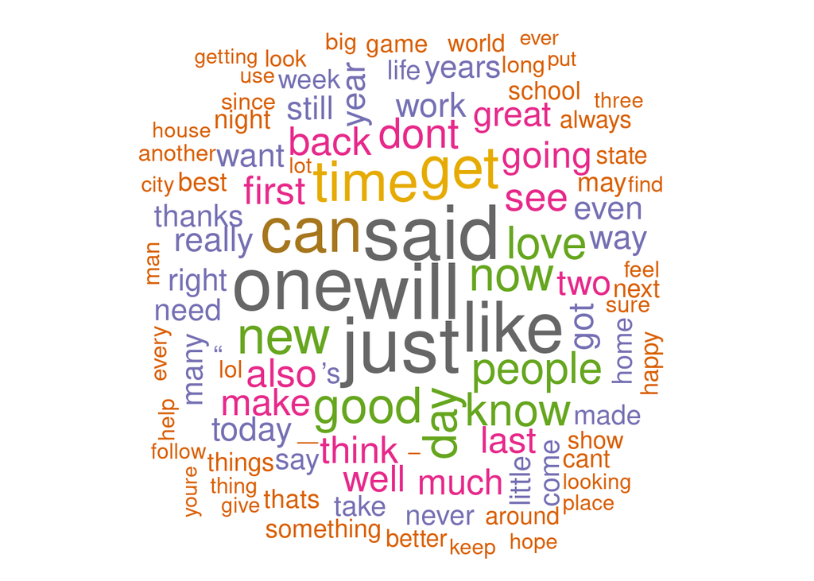

```r
set.seed(1827)
wordcloud(tdm_unigram, max.words=100, random.order=FALSE, colors=brewer.pal(8, "Dark2"))
```

[figure not shown]

```r
wordcloud(tdm_bigram, max.words=100, random.order=FALSE, colors=brewer.pal(8, "Dark2"))
```

[figure not shown]

```r
wordcloud(tdm_trigram, max.words=100, random.order=FALSE, colors=brewer.pal(8, "Dark2"))
```

### Capstone Project Next Steps

Next, I will build a prediction model by utilizing the unigram, bigram, and trigram token data. During this process, I’ll be looking for various ways to make the code efficient and try to limit programming run time without sacrificing too much accuracy. Multiple modeling techniques will be considered.

Finally, a shiny application will be developed allowing the user to see predictive words appear as they start typing in text. This would work in a similar manner to how texting works on a smartphone.